# Interpretable ML package

Joshua Loftus

## Random forest to classify penguins

```r
pg <- penguins %>%
  # not interested in classifying by time/island
  dplyr::select(-island, -year, -sex) %>%
  drop_na()
```

#### First fit a single tree

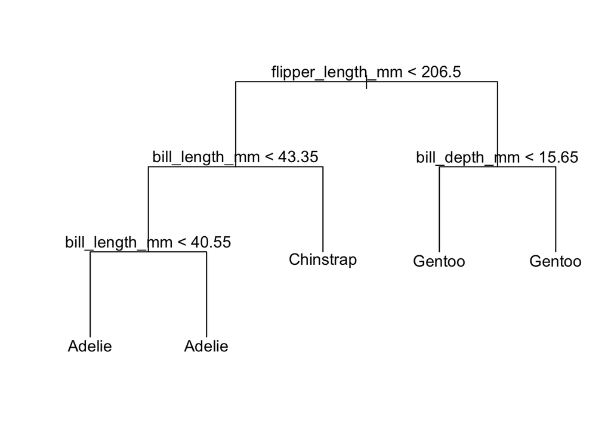

```r
fit_tree <- tree(species ~ .,
                 split = "gini",
                 control = tree.control(nrow(pg), mincut = 40),
                 data = pg)
plot(fit_tree, type = "uniform")
text(fit_tree, pretty = 0, cex = 1.1)
```

#### Experiment with changing the control parameters

#### Fit a random forest

```r
fit_rf <- randomForest(species ~ ., ntree = 100, mtry = 2,
                  minsize = 20, data = pg)
fit_rf
```

```
##
## Call:
##  randomForest(formula = species ~ ., data = pg, ntree = 100, mtry = 2,      minsize = 20)
##                Type of random forest: classification
##                      Number of trees: 100
## No. of variables tried at each split: 2
##
##         OOB estimate of  error rate: 2.63%
## Confusion matrix:
##           Adelie Chinstrap Gentoo class.error
## Adelie       147         3      1 0.026490066
## Chinstrap      4        64      0 0.058823529
## Gentoo         0         1    122 0.008130081
```

#### Variable importance plot

Read `?importance` to learn more

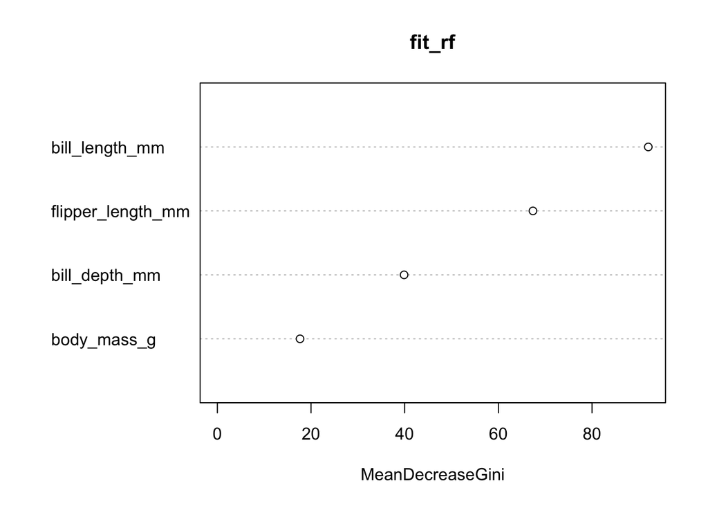

```r
varImpPlot(fit_rf)
```

#### Experiment with changing the control parameters

#### Partial dependence plots

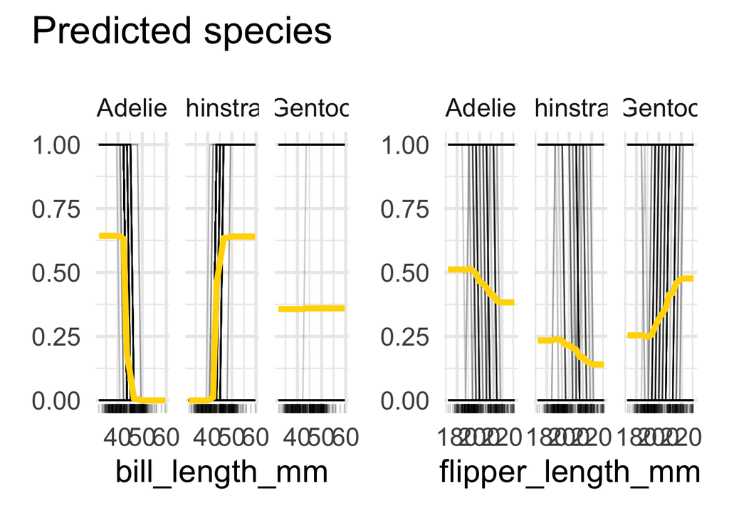

```r
pred_rf <- Predictor$new(fit_rf)
pdp_rf <- FeatureEffects$new(pred_rf,
      features = c("bill_length_mm",
                   "flipper_length_mm"#,
                   #"bill_depth_mm",
                   #"body_mass_g"
                   ), method = "pdp+ice")
plot(pdp_rf)
```

#### Interaction plots

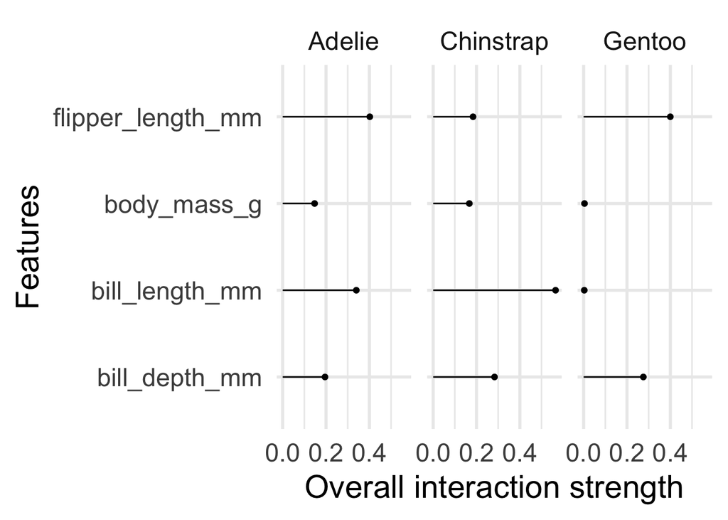

```r
int_rf <- Interaction$new(pred_rf)
plot(int_rf)
```

#### For each variable, how much does the model’s predictions depend on the interaction of that variable with others or by the variable alone?

Hint: read `?Interaction`

If the measure is close to 0 then the predictions depend mostly on the variable alone, if it’s close to 1 then the predictions depend more on interactions between that variable and other predictors

#### Fit a gam and interpret the interaction plot for the fitted model

Note that the `iml` and `gam` packages are slightly less compatible, e.g. it seems that `iml` plots will automatically show results for only 1 class

```r
fit_gam <- gam(species ~ ., family = "binomial",  data = pg)
fit_gam
```

```
## Call:
## gam(formula = species ~ ., family = "binomial", data = pg)
##
## Degrees of Freedom: 341 total; 337 Residual
## Residual Deviance: 9.44917
```

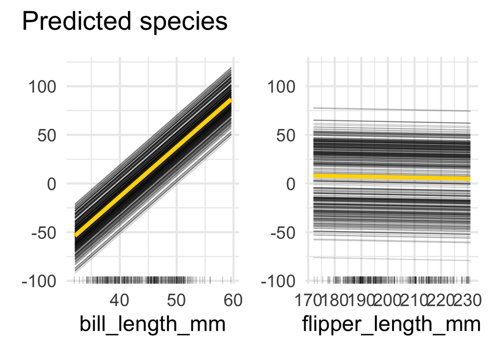

```r
pred_gam <- Predictor$new(fit_gam)#, type = "response")
pdp_gam <- FeatureEffects$new(pred_gam,
      features = c("bill_length_mm",
                   "flipper_length_mm"#,
                   #"bill_depth_mm",
                   #"body_mass_g"
                   ), method = "pdp+ice")
plot(pdp_gam)
```

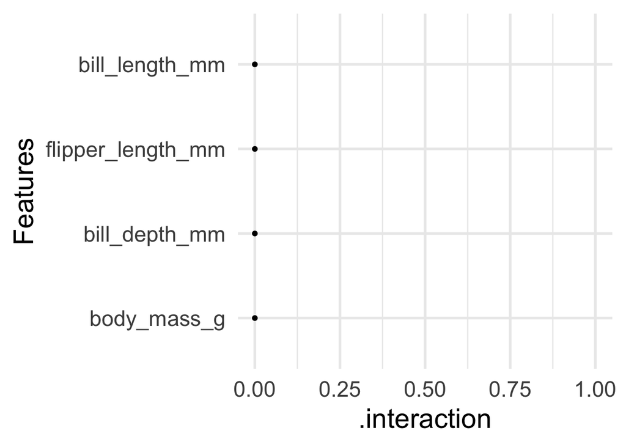

```r
int_gam <- Interaction$new(pred_gam)
plot(int_gam) + xlim(c(0,1))
```

#### Is this what we expect?

Yes, the additivity assumption of GAMs means the model’s predictions cannot possibly depend on interactions